# Luxembourg Research Evaluation 2022

Daniel S. Hain

10 June, 2022

# 1 Initial Corpus generation

# 2 General Overview over articles

## 2.1 Main Indicators: Publications, Authors, Countries

To start with, a general overview over the documents in the corpus.

```
MAIN INFORMATION ABOUT DATA

 Timespan                              1973 : 2022
 Sources (Journals, Books, etc)        1708
 Documents                             7658
 Average years from publication        3.85
 Average citations per documents       20.21
 Average citations per year per doc    4.025
 References                            373854

DOCUMENT TYPES
 article               7572
 book                  2
 book chapter          23
 conference paper      12
 data paper            1
 editorial             25
 review                22
 short survey          1

DOCUMENT CONTENTS
 Keywords Plus (ID)                    13660
 Author's Keywords (DE)                16355

AUTHORS
 Authors                               17150
 Author Appearances                    29186
 Authors of single-authored documents  1088
 Authors of multi-authored documents   16062

AUTHORS COLLABORATION
 Single-authored documents             1268
 Documents per Author                  0.447
 Authors per Document                  2.24
 Co-Authors per Documents              3.81
 Collaboration Index                   2.51


Annual Scientific Production
```

| Year | Articles |
| --- | --- |
| 1973 | 1 |
| 1978 | 3 |
| 1990 | 2 |
| 1991 | 1 |
| 1995 | 3 |
| 1996 | 4 |
| 1997 | 2 |
| 1998 | 3 |
| 1999 | 7 |
| 2000 | 4 |

[output cut: 22 more lines]

```
Annual Percentage Growth Rate 6.076164


Most Productive Authors
```

|  | Authors | Articles | Authors | Articles Fractionalized |
| --- | --- | --- | --- | --- |
| 1 | LIU Y | 127 | LIU Y | 28.0 |
| 2 | LI X | 77 | CHEN Y | 19.2 |
| 3 | ZHANG Y | 75 | LI X | 16.6 |
| 4 | CHEN Y | 63 | LAMOUR C | 16.5 |
| 5 | LI Y | 62 | ZHANG Y | 15.8 |
| 6 | WANG X | 59 | DE VOS J | 14.8 |
| 7 | LIU X | 55 | LI Y | 14.7 |
| 8 | WANG Y | 55 | WANG X | 13.3 |
| 9 | WANG J | 51 | WANG J | 12.4 |
| 10 | ZHANG X | 41 | WANG Y | 12.2 |

```
Top manuscripts per citations
```

|  | Paper | DOI | TC | TCperYear | NTC |
| --- | --- | --- | --- | --- | --- |
| 1 | FELDMAN MP, 1999, EUR ECON REV | 10.1016/S0014-2921(98)00047-6 | 1070 | 44.6 | 4.28 |
| 2 | DING D, 2016, LANCET | 10.1016/S0140-6736(16)30383-X | 923 | 131.9 | 27.42 |
| 3 | GUTHOLD R, 2020, LANCET CHILD ADOLESC HEALTH | 10.1016/S2352-4642(19)30323-2 | 707 | 235.7 | 58.17 |
| 4 | WHITING P, 2016, J CLIN EPIDEMIOL | 10.1016/j.jclinepi.2015.06.005 | 627 | 89.6 | 18.63 |
| 5 | SALLIS JF, 2016, LANCET | 10.1016/S0140-6736(15)01284-2 | 596 | 85.1 | 17.71 |
| 6 | LIU X, 2017, LANDSC URBAN PLANN | 10.1016/j.landurbplan.2017.09.019 | 475 | 79.2 | 18.08 |
| 7 | ESTOQUE RC, 2017, SCI TOTAL ENVIRON | 10.1016/j.scitotenv.2016.10.195 | 469 | 78.2 | 17.85 |
| 8 | TWOHIG-BENNETT C, 2018, ENVIRON RES | 10.1016/j.envres.2018.06.030 | 464 | 92.8 | 21.91 |
| 9 | MARTIN P, 1995, J INT ECON | 10.1016/0022-1996(95)01376-6 | 365 | 13.0 | 2.31 |
| 10 | DE VOS J, 2020, TRANSP RES INTERDISCIP PERSPECT | 10.1016/j.trip.2020.100121 | 359 | 119.7 | 29.54 |

```
Corresponding Author's Countries
```

|  | Country | Articles | Freq | SCP | MCP | MCP_Ratio |
| --- | --- | --- | --- | --- | --- | --- |
| 1 | USA | 1160 | 0.1804 | 926 | 234 | 0.202 |
| 2 | CHINA | 1154 | 0.1795 | 773 | 381 | 0.330 |
| 3 | UNITED KINGDOM | 536 | 0.0834 | 366 | 170 | 0.317 |
| 4 | CANADA | 305 | 0.0474 | 236 | 69 | 0.226 |
| 5 | AUSTRALIA | 300 | 0.0467 | 209 | 91 | 0.303 |
| 6 | NETHERLANDS | 273 | 0.0425 | 181 | 92 | 0.337 |
| 7 | SPAIN | 224 | 0.0348 | 153 | 71 | 0.317 |
| 8 | GERMANY | 212 | 0.0330 | 139 | 73 | 0.344 |
| 9 | ITALY | 143 | 0.0222 | 102 | 41 | 0.287 |
| 10 | SWEDEN | 139 | 0.0216 | 96 | 43 | 0.309 |

```
SCP: Single Country Publications

MCP: Multiple Country Publications


Total Citations per Country
```

|  | Country | Total Citations | Average Article Citations |
| --- | --- | --- | --- |
| 1 | USA | 26373 | 22.74 |
| 2 | CHINA | 24997 | 21.66 |
| 3 | UNITED KINGDOM | 12540 | 23.40 |
| 4 | NETHERLANDS | 6899 | 25.27 |
| 5 | AUSTRALIA | 6242 | 20.81 |
| 6 | CANADA | 6168 | 20.22 |
| 7 | GERMANY | 4619 | 21.79 |
| 8 | SPAIN | 4015 | 17.92 |
| 9 | BELGIUM | 3277 | 27.77 |
| 10 | ITALY | 2874 | 20.10 |

```
Most Relevant Sources
```

|  | Sources | Articles |
| --- | --- | --- |
| 1 | SUSTAINABILITY (SWITZERLAND) | 259 |
| 2 | INTERNATIONAL JOURNAL OF ENVIRONMENTAL RESEARCH AND PUBLIC HEALTH | 171 |
| 3 | PLOS ONE | 152 |
| 4 | LAND USE POLICY | 141 |
| 5 | JOURNAL OF TRANSPORT GEOGRAPHY | 133 |
| 6 | URBAN STUDIES | 125 |
| 7 | TRANSPORTATION RESEARCH PART A: POLICY AND PRACTICE | 124 |
| 8 | CITIES | 115 |
| 9 | BMC PUBLIC HEALTH | 108 |
| 10 | TRANSPORTATION RESEARCH PART D: TRANSPORT AND ENVIRONMENT | 101 |

```
Most Relevant Keywords
```

|  | Author Keywords (DE) | Articles | Keywords-Plus (ID) | Articles |
| --- | --- | --- | --- | --- |
| 1 | PHYSICAL ACTIVITY | 626 | FEMALE | 2258 |
| 2 | BUILT ENVIRONMENT | 330 | MALE | 2195 |
| 3 | GENTRIFICATION | 242 | EXERCISE | 1722 |
| 4 | URBANIZATION | 236 | HUMAN | 1660 |
| 5 | CHINA | 235 | HUMANS | 1384 |
| 6 | CHILDREN | 138 | CHINA | 1197 |
| 7 | LAND USE | 126 | ARTICLE | 1152 |
| 8 | TRAVEL BEHAVIOR | 124 | ADULT | 1115 |
| 9 | EXERCISE | 121 | CHILD | 1066 |
| 10 | WALKING | 120 | ADOLESCENT | 1048 |

```
NA
```

And a graphical visualization

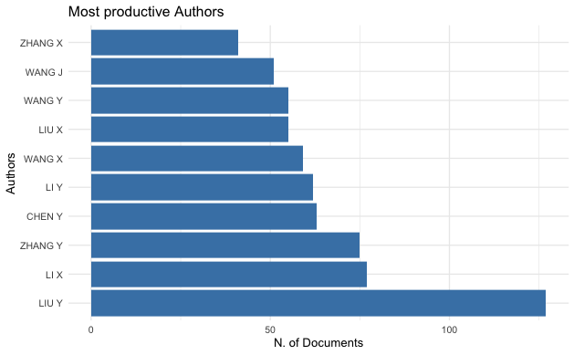

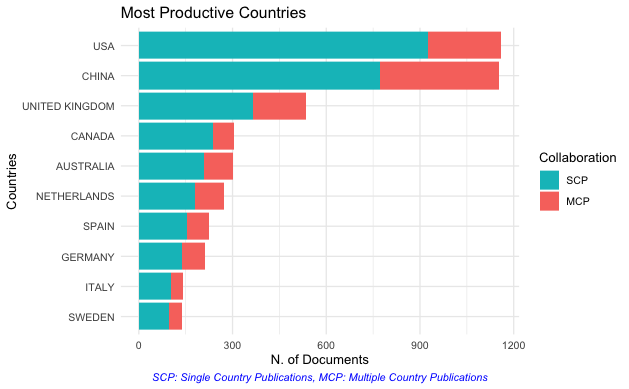

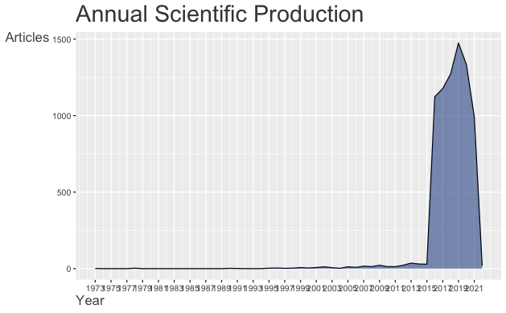

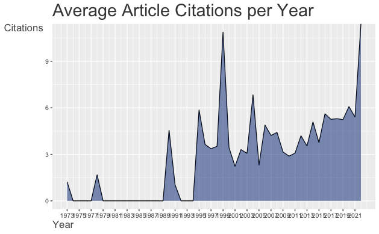

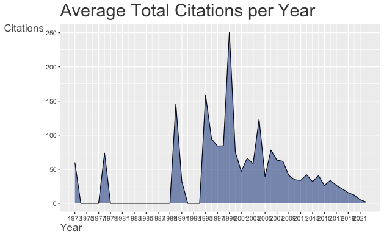

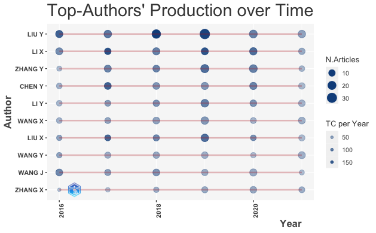

## 2.2 Cited references

Top 20 cited references (by corpus documents):

| CR | n |
| --- | --- |
| JANSSEN, I., LEBLANC, A.G., SYSTEMATIC REVIEW OF THE HEALTH BENEFITS OF PHYSICAL ACTIVITY AND FITNESS IN SCHOOL-AGED CHILDREN AND YOUTH (2010) INT J BEHAV NUTR PHYS ACT, 7, P. 40 | 78 |
| EWING, R., CERVERO, R., TRAVEL AND THE BUILT ENVIRONMENT: A META-ANALYSIS (2010) JOURNAL OF THE AMERICAN PLANNING ASSOCIATION, 76 (3), PP. 265-294 | 75 |
| SMITH, N., TOWARD A THEORY OF GENTRIFICATION: A BACK TO THE CITY MOVEMENT BY CAPITAL, NOT PEOPLE (1979) JOURNAL OF THE AMERICAN PLANNING ASSOCIATION, 45 (4), PP. 538-548 | 65 |
| CERVERO, R., KOCKELMAN, K., TRAVEL DEMAND AND THE 3DS: DENSITY, DIVERSITY, AND DESIGN (1997) TRANSPORTATION RESEARCH PART D: TRANSPORT AND ENVIRONMENT, 2 (3), PP. 199-219 | 64 |
| CHARLES, C.Z., THE DYNAMICS OF RACIAL RESIDENTIAL SEGREGATION (2003) ANNUAL REVIEW OF SOCIOLOGY, 29, PP. 167-207 | 64 |
| HALLAL, P.C., ANDERSEN, L.B., BULL, F.C., GUTHOLD, R., HASKELL, W., EKELUND, U., GLOBAL PHYSICAL ACTIVITY LEVELS: SURVEILLANCE PROGRESS, PITFALLS, AND PROSPECTS (2012) LANCET, 380, PP. 247-257 | 64 |
| SMITH, N., NEW GLOBALISM, NEW URBANISM: GENTRIFICATION AS GLOBAL URBAN STRATEGY (2002) ANTIPODE, 34 (3), PP. 427-450 | 62 |
| BETTENCOURT, L.M.A., THE ORIGINS OF SCALING IN CITIES (2013) SCIENCE, 340, PP. 1438-1441 | 59 |
| WACHSMUTH, D., WEISLER, A., AIRBNB AND THE RENT GAP: GENTRIFICATION THROUGH THE SHARING ECONOMY (2018) ENVIRONMENT AND PLANNING A: ECONOMY AND SPACE, 50 (6), PP. 1147-1170 | 57 |
| EWING, R., CERVERO, R., TRAVEL AND THE BUILT ENVIRONMENT: A META-ANALYSIS (2010) J. AM. PLAN. ASSOC., 76 (3), PP. 265-294 | 55 |
| GRIMM, N.B., FAETH, S.H., GOLUBIEWSKI, N.E., REDMAN, C.L., WU, J., BAI, X., BRIGGS, J.M., GLOBAL CHANGE AND THE ECOLOGY OF CITIES (2008) SCIENCE, 319, PP. 756-760 | 54 |
| DE VOS, J., MOKHTARIAN, P.L., SCHWANEN, T., VAN ACKER, V., WITLOX, F., TRAVEL MODE CHOICE AND TRAVEL SATISFACTION: BRIDGING THE GAP BETWEEN DECISION UTILITY AND EXPERIENCED UTILITY (2016) TRANSPORTATI… | 51 |
| HALLAL, P.C., ANDERSEN, L.B., BULL, F.C., GUTHOLD, R., HASKELL, W., EKELUND, U., GLOBAL PHYSICAL ACTIVITY LEVELS: SURVEILLANCE PROGRESS, PITFALLS, AND PROSPECTS (2012) LANCET, 380 (9838), PP. 247-257 | 48 |
| EWING, R., CERVERO, R., TRAVEL AND THE BUILT ENVIRONMENT (2010) JOURNAL OF THE AMERICAN PLANNING ASSOCIATION, 76 (3), PP. 265-294 | 46 |
| HACKWORTH, J., SMITH, N., THE CHANGING STATE OF GENTRIFICATION (2001) TIJDSCHRIFT VOOR ECONOMISCHE EN SOCIALE GEOGRAFIE, 92 (4), PP. 464-477 | 45 |
| LIU, Y., FANG, F., LI, Y., KEY ISSUES OF LAND USE IN CHINA AND IMPLICATIONS FOR POLICY MAKING (2014) LAND USE POLICY, 40, PP. 6-12 | 44 |
| MORRIS, E.A., GUERRA, E., MOOD AND MODE: DOES HOW WE TRAVEL AFFECT HOW WE FEEL? (2015) TRANSPORTATION, 42 (1), PP. 25-43 | 44 |
| SETO, K.C., GÜNERALP, B., HUTYRA, L.R., GLOBAL FORECASTS OF URBAN EXPANSION TO 2030 AND DIRECT IMPACTS ON BIODIVERSITY AND CARBON POOLS (2012) PROC. NATL. ACAD. SCI. USA, 109, PP. 16083-16088 | 44 |
| BATTY, M., THE SIZE, SCALE, AND SHAPE OF CITIES (2008) SCIENCE, 319, PP. 769-771 | 43 |
| KITAMURA, R., MOKHTARIAN, P.L., LAIDET, L., A MICRO-ANALYSIS OF LAND USE AND TRAVEL IN FIVE NEIGHBORHOODS IN THE SAN FRANCISCO BAY AREA (1997) TRANSPORTATION, 24 (2), PP. 125-158 | 43 |

# 3 Topic modelling

## 3.1 Topics by topwords

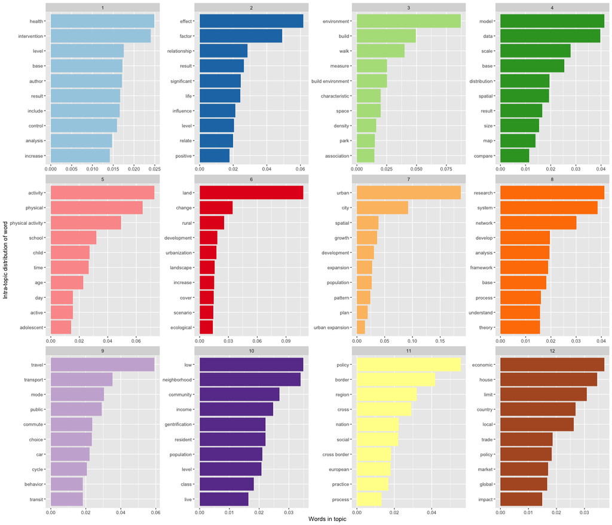

This might still be finetuned, but initially doesnt look that bad I think. All the topics for me seem to be somewhat identifiable. We should maybe start naming them to make their interpretation later easier.

## 3.2 Topics over time

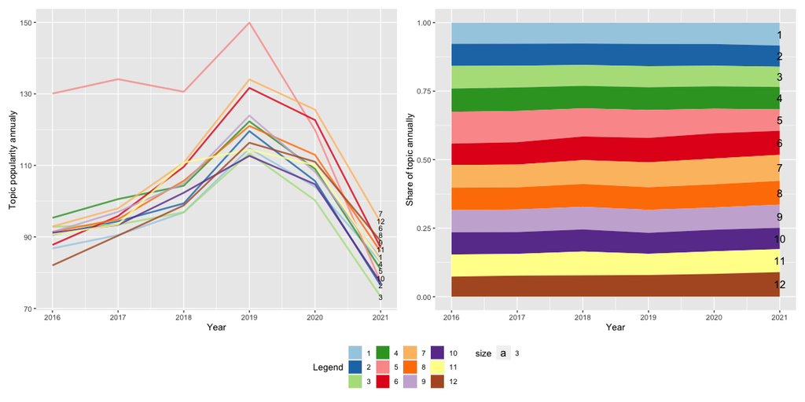

## 3.3 LDAViz

# 4 Knowledge Bases: Co-Citation network analysis

**Note:** This analysis refers the co-citation analysis, where the cited references and not the original publications are the unit of analysis. See tab `Technical description`for additional explanations

## 4.1 Knowledge Bases summary

### 4.1.1 Main Indicators

In order to partition networks into components or clusters, we deploy a **community detection** technique based on the **Lovain Algorithm** (Blondel et al., 2008). The Lovain Algorithm is a heuristic method that attempts to optimize the modularity of communities within a network by maximizing within- and minimizing between-community connectivity. We identify the following communities = knowledge bases.

| com_name | n | density_int |
| --- | --- | --- |
| 1 | 1639 | 3.925 |
| 2 | 1170 | 3.306 |
| 3 | 1014 | 4.669 |
| 4 | 1011 | 2.669 |
| 5 | 931 | 4.083 |
| 6 | 774 | 6.627 |
| 7 | 667 | 15.399 |
| 8 | 582 | 6.139 |

| com | name | dgr_int | dgr |
| --- | --- | --- | --- |
| 1 | CERVERO R. KOCKELMAN K. TRAVEL DEMAND AND THE 3DS: DENSITY DIVERSITY AND DESIGN (1997) | 4342 | 4875 |
| 1 | EWING R. CERVERO R. TRAVEL AND THE BUILT ENVIRONMENT: A META-ANALYSIS (2010) | 3100 | 3565 |
| 1 | MOKHTARIAN P.L. CAO X. EXAMINING THE IMPACTS OF RESIDENTIAL SELF-SELECTION ON TRAVEL BEHAVIOR: A FOCUS ON METHODOLOGIES (2008) | 2138 | 2382 |
| 1 | EWING R. CERVERO R. TRAVEL AND THE BUILT ENVIRONMENT (2010) | 2091 | 2345 |
| 1 | SAELENS B.E. HANDY S.L. BUILT ENVIRONMENT CORRELATES OF WALKING: A REVIEW (2008) | 1964 | 2262 |
| 1 | EWING R. CERVERO R. TRAVEL AND THE BUILT ENVIRONMENT: A SYNTHESIS (2001) | 1904 | 2172 |
| 1 | HANDY S. CAO X. MOKHTARIAN P. CORRELATION OR CAUSALITY BETWEEN THE BUILT ENVIRONMENT AND TRAVEL BEHAVIOR? EVIDENCE FROM NORTHERN CALIFORNIA (2005) | 1800 | 2046 |
| 1 | SAELENS B.E. SALLIS J.F. FRANK L.D. ENVIRONMENTAL CORRELATES OF WALKING AND CYCLING: FINDINGS FROM THE TRANSPORTATION URBAN DESIGN AND PLANNING LIT... | 1744 | 2048 |
| 1 | CAO X. MOKHTARIAN P.L. HANDY S.L. EXAMINING THE IMPACTS OF RESIDENTIAL SELF-SELECTION ON TRAVEL BEHAVIOUR: A FOCUS ON EMPIRICAL FINDINGS (2009) | 1475 | 1860 |
| 1 | BHAT C.R. GUO J.Y. A COMPREHENSIVE ANALYSIS OF BUILT ENVIRONMENT CHARACTERISTICS ON HOUSEHOLD RESIDENTIAL CHOICE AND AUTO OWNERSHIP LEVELS (2007) | 1241 | 1287 |
| 2 | SETO K.C. GÜNERALP B. HUTYRA L.R. GLOBAL FORECASTS OF URBAN EXPANSION TO 2030 AND DIRECT IMPACTS ON BIODIVERSITY AND CARBON POOLS (2012) | 1545 | 1854 |
| 2 | SETO K.C. FRAGKIAS M. GÜNERALP B. REILLY M.K. A META-ANALYSIS OF GLOBAL URBAN LAND EXPANSION (2011) | 1065 | 1192 |
| 2 | LI X. ZHOU W. OUYANG Z. FORTY YEARS OF URBAN EXPANSION IN BEIJING: WHAT IS THE RELATIVE IMPORTANCE OF PHYSICAL SOCIOECONOMIC AND NEIGHBORHOOD FACTO... | 827 | 983 |
| 2 | SCHNEIDER A. WOODCOCK C.E. COMPACT DISPERSED FRAGMENTED EXTENSIVE? A COMPARISON OF URBAN GROWTH IN TWENTY-FIVE GLOBAL CITIES USING REMOTELY SENSED ... | 696 | 805 |
| 2 | GRIMM N.B. FAETH S.H. GOLUBIEWSKI N.E. REDMAN C.L. WU J. BAI X. BRIGGS J.M. GLOBAL CHANGE AND THE ECOLOGY OF CITIES (2008) | 656 | 730 |
| 2 | SETO K.C. GUNERALP B. HUTYRA L.R. GLOBAL FORECASTS OF URBAN EXPANSION TO 2030 AND DIRECT IMPACTS ON BIODIVERSITY AND CARBON POOLS (2012) | 588 | 683 |
| 2 | GALSTER G. HANSON R. RATCLIFFE M.R. WOLMAN H. COLEMAN S. FREIHAGE J. WRESTLING SPRAWL TO THE GROUND: DEFINING AND MEASURING AN ELUSIVE CONCEPT (2001) | 563 | 642 |
| 2 | ANGEL S. PARENT J. CIVCO D.L. BLEI A. POTERE D. THE DIMENSIONS OF GLOBAL URBAN EXPANSION: ESTIMATES AND PROJECTIONS FOR ALL COUNTRIES 2000–2050 (2011) | 461 | 501 |
| 2 | BHATTA B. SARASWATI S. BANDYOPADHYAY D. URBAN SPRAWL MEASUREMENT FROM REMOTE SENSING DATA (2010) | 374 | 406 |
| 2 | JIAO L. URBAN LAND DENSITY FUNCTION: A NEW METHOD TO CHARACTERIZE URBAN EXPANSION (2015) | 369 | 414 |
| 3 | SMITH N. (1996) | 2057 | 2060 |
| 3 | SMITH N. TOWARD A THEORY OF GENTRIFICATION: A BACK TO THE CITY MOVEMENT BY CAPITAL NOT PEOPLE (1979) | 1158 | 1170 |
| 3 | SMITH N. NEW GLOBALISM NEW URBANISM: GENTRIFICATION AS GLOBAL URBAN STRATEGY (2002) | 1137 | 1140 |
| 3 | HACKWORTH J. SMITH N. THE CHANGING STATE OF GENTRIFICATION (2001) | 979 | 979 |
| 3 | LEES L. SLATER T. WYLY E. (2008) | 952 | 955 |
| 3 | FREEMAN L. DISPLACEMENT OR SUCCESSION? RESIDENTIAL MOBILITY IN GENTRIFYING NEIGHBORHOODS (2005) | 878 | 881 |
| 3 | LEY D. (1996) | 826 | 839 |
| 3 | SLATER T. THE EVICTION OF CRITICAL PERSPECTIVES FROM GENTRIFICATION RESEARCH (2006) | 743 | 743 |
| 3 | MARCUSE P. GENTRIFICATION ABANDONMENT AND DISPLACEMENT: CONNECTIONS CAUSES AND POLICY RESPONSES IN NEW YORK CITY (1985) | 588 | 588 |
| 3 | NEWMAN K. WYLY E.K. THE RIGHT TO STAY PUT REVISITED: GENTRIFICATION AND RESISTANCE TO DISPLACEMENT IN NEW YORK CITY (2006) | 580 | 580 |
| 4 | JANSSEN I. LEBLANC A.G. SYSTEMATIC REVIEW OF THE HEALTH BENEFITS OF PHYSICAL ACTIVITY AND FITNESS IN SCHOOL-AGED CHILDREN AND YOUTH (2010) | 2411 | 2495 |
| 4 | HALLAL P.C. ANDERSEN L.B. BULL F.C. GUTHOLD R. HASKELL W. EKELUND U. GLOBAL PHYSICAL ACTIVITY LEVELS: SURVEILLANCE PROGRESS PITFALLS AND PROSPECTS ... | 1312 | 1616 |
| 4 | SALLIS J.F. CERVERO R.B. ASCHER W. HENDERSON K.A. KRAFT M.K. KERR J. AN ECOLOGICAL APPROACH TO CREATING ACTIVE LIVING COMMUNITIES (2006) | 976 | 1758 |
| 4 | EVENSON K.R. CATELLIER D.J. GILL K. ONDRAK K.S. MCMURRAY R.G. CALIBRATION OF TWO OBJECTIVE MEASURES OF PHYSICAL ACTIVITY FOR CHILDREN (2008) | 843 | 869 |
| 4 | SALLIS J.F. PROCHASKA J.J. TAYLOR W.C. A REVIEW OF CORRELATES OF PHYSICAL ACTIVITY OF CHILDREN AND ADOLESCENTS (2000) | 740 | 789 |
| 4 | BEETS M.W. CARDINAL B.J. ALDERMAN B.L. PARENTAL SOCIAL SUPPORT AND THE PHYSICAL ACTIVITY-RELATED BEHAVIORS OF YOUTH: A REVIEW (2010) | 502 | 510 |
| 4 | DUMITH S.C. GIGANTE D.P. DOMINGUES M.R. KOHL H.W. PHYSICAL ACTIVITY CHANGE DURING ADOLESCENCE: A SYSTEMATIC REVIEW AND A POOLED ANALYSIS (2011) | 431 | 434 |
| 4 | GUSTAFSON S.L. RHODES R.E. PARENTAL CORRELATES OF PHYSICAL ACTIVITY IN CHILDREN AND EARLY ADOLESCENTS (2006) | 349 | 355 |
| 4 | TELAMA R. TRACKING OF PHYSICAL ACTIVITY FROM CHILDHOOD TO ADULTHOOD: A REVIEW (2009) | 327 | 339 |
| 4 | TROST S.G. LOPRINZI P.D. MOORE R. PFEIFFER K.A. COMPARISON OF ACCELEROMETER CUT POINTS FOR PREDICTING ACTIVITY INTENSITY IN YOUTH (2011) | 318 | 321 |
| 5 | BETTENCOURT L.M.A. THE ORIGINS OF SCALING IN CITIES (2013) | 992 | 1013 |
| 5 | BATTY M. THE SIZE SCALE AND SHAPE OF CITIES (2008) | 749 | 912 |
| 5 | ALONSO W. (1964) | 730 | 803 |
| 5 | MILLS E.S. AN AGGREGATIVE MODEL OF RESOURCE ALLOCATION IN A METROPOLITAN AREA (1967) | 656 | 672 |
| 5 | BETTENCOURT L.M.A. LOBO J. HELBING D. KÜHNERT C. WEST G.B. GROWTH INNOVATION SCALING AND THE PACE OF LIFE IN CITIES (2007) | 574 | 599 |
| 5 | ARCAUTE E. HATNA E. FERGUSON P. YOUN H. JOHANSSON A. BATTY M. CONSTRUCTING CITIES DECONSTRUCTING SCALING LAWS (2015) | 564 | 570 |
| 5 | GABAIX X. ZIPF'S LAW FOR CITIES: AN EXPLANATION (1999) | 551 | 557 |
| 5 | EECKHOUT J. GIBRAT'S LAW FOR (ALL) | 483 | 483 |
| 5 | ROZENFELD H.D. RYBSKI D. GABAIX X. MAKSE H.A. THE AREA AND POPULATION OF CITIES: NEW INSIGHTS FROM A DIFFERENT PERSPECTIVE ON CITIES (2011) | 429 | 459 |
| 5 | BATTY M. (2013) | 355 | 412 |
| 6 | WU F. CALIBRATION OF STOCHASTIC CELLULAR AUTOMATA: THE APPLICATION TO RURAL-URBAN LAND CONVERSIONS (2002) | 1239 | 1299 |
| 6 | CLARKE K.C. HOPPEN S. GAYDOS L. A SELF-MODIFYING CELLULAR AUTOMATON MODEL OF HISTORICAL URBANIZATION IN THE SAN FRANCISCO BAY AREA (1997) | 1108 | 1190 |
| 6 | CLARKE K.C. GAYDOS L.J. LOOSE-COUPLING A CELLULAR AUTOMATON MODEL AND GIS: LONG-TERM URBAN GROWTH PREDICTION FOR SAN FRANCISCO AND WASHINGTON/BALTI... | 1069 | 1209 |
| 6 | BATTY M. XIE Y. SUN Z. MODELING URBAN DYNAMICS THROUGH GIS-BASED CELLULAR AUTOMATA (1999) | 884 | 928 |
| 6 | PIJANOWSKI B.C. BROWN D.G. SHELLITO B.A. MANIK G.A. USING NEURAL NETWORKS AND GIS TO FORECAST LAND USE CHANGES: A LAND TRANSFORMATION MODEL (2002) | 829 | 881 |
| 6 | WHITE R. ENGELEN G. CELLULAR AUTOMATA AND FRACTAL URBAN FORM: A CELLULAR MODELLING APPROACH TO THE EVOLUTION OF URBAN LAND-USE PATTERNS (1993) | 628 | 658 |
| 6 | WU F. WEBSTER C.J. SIMULATION OF LAND DEVELOPMENT THROUGH THE INTEGRATION OF CELLULAR AUTOMATA AND MULTICRITERIA EVALUATION (1998) | 545 | 555 |
| 6 | YANG Q. LI X. SHI X. CELLULAR AUTOMATA FOR SIMULATING LAND USE CHANGES BASED ON SUPPORT VECTOR MACHINES (2008) | 543 | 556 |
| 6 | TAYYEBI A. PIJANOWSKI B.C. MODELING MULTIPLE LAND USE CHANGES USING ANN CART AND MARS: COMPARING TRADEOFFS IN GOODNESS OF FIT AND EXPLANATORY POWER... | 535 | 581 |
| 6 | SANTÉ I. GARCÍA A.M. MIRANDA D. CRECENTE R. CELLULAR AUTOMATA MODELS FOR THE SIMULATION OF REAL-WORLD URBAN PROCESSES: A REVIEW AND ANALYSIS (2010) | 534 | 567 |
| 7 | OLSSON L.E. GÄRLING T. ETTEMA D. FRIMAN M. FUJII S. HAPPINESS AND SATISFACTION WITH WORK COMMUTE (2013) | 2117 | 2303 |
| 7 | DE VOS J. SCHWANEN T. VAN ACKER V. WITLOX F. TRAVEL AND SUBJECTIVE WELL-BEING: A FOCUS ON FINDINGS METHODS AND FUTURE RESEARCH NEEDS (2013) | 1972 | 2212 |
| 7 | ST-LOUIS E. MANAUGH K. VAN LIEROP D. EL-GENEIDY A. THE HAPPY COMMUTER: A COMPARISON OF COMMUTER SATISFACTION ACROSS MODES (2014) | 1912 | 2139 |
| 7 | ETTEMA D. GÄRLING T. ERIKSSON L. FRIMAN M. OLSSON L.E. FUJII S. SATISFACTION WITH TRAVEL AND SUBJECTIVE WELL-BEING: DEVELOPMENT AND TEST OF A MEASU... | 1846 | 2020 |
| 7 | ETTEMA D. GÄRLING T. OLSSON L.E. FRIMAN M. OUT-OF-HOME ACTIVITIES DAILY TRAVEL AND SUBJECTIVE WELL-BEING (2010) | 1687 | 1808 |
| 7 | DE VOS J. MOKHTARIAN P.L. SCHWANEN T. VAN ACKER V. WITLOX F. TRAVEL MODE CHOICE AND TRAVEL SATISFACTION: BRIDGING THE GAP BETWEEN DECISION UTILITY ... | 1609 | 1939 |
| 7 | YE R. TITHERIDGE H. SATISFACTION WITH THE COMMUTE: THE ROLE OF TRAVEL MODE CHOICE BUILT ENVIRONMENT AND ATTITUDES (2017) | 1506 | 1729 |
| 7 | MORRIS E.A. GUERRA E. MOOD AND MODE: DOES HOW WE TRAVEL AFFECT HOW WE FEEL? (2015) | 1394 | 1553 |
| 7 | FRIMAN M. FUJII S. ETTEMA D. GÄRLING T. OLSSON L.E. PSYCHOMETRIC ANALYSIS OF THE SATISFACTION WITH TRAVEL SCALE (2013) | 1373 | 1539 |
| 7 | ETTEMA D. FRIMAN M. GÄRLING T. OLSSON L.E. FUJII S. HOW IN-VEHICLE ACTIVITIES AFFECT WORK COMMUTERS’ SATISFACTION WITH PUBLIC TRANSPORT (2012) | 1006 | 1062 |
| 8 | AJZEN I. THE THEORY OF PLANNED BEHAVIOR (1991) | 1188 | 2336 |
| 8 | HEINEN E. VAN WEE B. MAAT K. COMMUTING BY BICYCLE: AN OVERVIEW OF THE LITERATURE (2010) | 692 | 855 |
| 8 | STEG L. CAR USE: LUST AND MUST. INSTRUMENTAL SYMBOLIC AND AFFECTIVE MOTIVES FOR CAR USE (2005) | 547 | 995 |
| 8 | BAMBERG S. AJZEN I. SCHMIDT P. CHOICE OF TRAVEL MODE IN THE THEORY OF PLANNED BEHAVIOR: THE ROLES OF PAST BEHAVIOR HABIT AND REASONED ACTION (2003) | 499 | 617 |
| 8 | PUCHER J. DILL J. HANDY S. INFRASTRUCTURE PROGRAMS AND POLICIES TO INCREASE BICYCLING: AN INTERNATIONAL REVIEW (2010) | 486 | 720 |
| 8 | HEINEN E. MAAT K. VAN WEE B. THE ROLE OF ATTITUDES TOWARD CHARACTERISTICS OF BICYCLE COMMUTING ON THE CHOICE TO CYCLE TO WORK OVER VARIOUS DISTANCE... | 475 | 687 |
| 8 | DILL J. VOROS K. FACTORS AFFECTING BICYCLING DEMAND: INITIAL SURVEY FINDINGS FROM THE PORTLAND OREGON REGION (2007) | 356 | 408 |
| 8 | GATERSLEBEN B. APPLETON K.M. CONTEMPLATING CYCLING TO WORK: ATTITUDES AND PERCEPTIONS IN DIFFERENT STAGES OF CHANGE (2007) | 352 | 382 |
| 8 | PUCHER J. BUEHLER R. MAKING CYCLING IRRESISTIBLE: LESSONS FROM THE NETHERLANDS DENMARK AND GERMANY (2008) | 343 | 510 |
| 8 | GÄRLING T. AXHAUSEN K.W. INTRODUCTION: HABITUAL TRAVEL CHOICE (2003) | 307 | 589 |

### 4.1.2 Development of Knowledge Bases

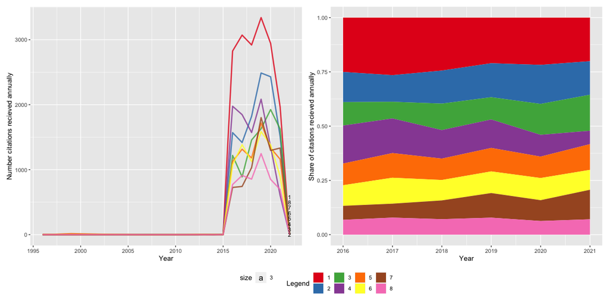

## 4.2 Technical description

In a co-cittion network, the strength of the relationship between a reference pair $m$ and $n$ ($s_{m,n}^{coc}$) is expressed by the number of publications $C$ which are jointly citing reference $m$ and $n$.

$$s_{m,n}^{coc} = \sum_i c_{i,m}
c_{i,n}$$

The intuition here is that references which are frequently cited together are likely to share commonalities in theory, topic, methodology, or context. It can be interpreted as a measure of similarity as evaluated by other researchers that decide to jointly cite both references. Because the publication process is time-consuming, co-citation is a backward-looking measure, which is appropriate to map the relationship between core literature of a field.

# 5 Research Areas: Bibliographic coupling analysis

## 5.1 Research Areas main summary

This is arguably the more interesting part. Here, we identify the literature’s current knowledge frontier by carrying out a bibliographic coupling analysis of the publications in our corpus. This measure uses bibliographical information of publications to establish a similarity relationship between them. Again, method details to be found in the tab `Technical description`. As you will see, we identify the main research area, but also a set of adjacent research areas with some theoretical/methodological/application overlap.

### 5.1.1 Main Characteristics

To identify communities in the field’s knowledge frontier (labeled **research areas**) we again use the **Lovain Algorithm** (Blondel et al., 2008). We identify the following communities = research areas.

| com | com_name | n | density_int |
| --- | --- | --- | --- |
| 1 | 1 | 1136 | 0.126 |
| 2 | 2 | 901 | 0.307 |
| 3 | 3 | 833 | 0.174 |
| 4 | 4 | 698 | 0.214 |
| 5 | 5 | 565 | 0.225 |
| 6 | 6 | 374 | 0.662 |
| 7 | 7 | 357 | 0.174 |
| 8 | 8 | 267 | 0.405 |

| com | com_name | topic_name |
| --- | --- | --- |
| 1 | 1 | 6 |
| 1 | 1 | 7 |
| 1 | 1 | 4 |
| 2 | 2 | 3 |
| 2 | 2 | 9 |
| 2 | 2 | 5 |
| 3 | 3 | 10 |
| 3 | 3 | 12 |
| 3 | 3 | 11 |
| 4 | 4 | 5 |
| 4 | 4 | 1 |
| 4 | 4 | 2 |
| 5 | 5 | 7 |
| 5 | 5 | 4 |
| 5 | 5 | 12 |
| 6 | 6 | 2 |
| 6 | 6 | 9 |
| 6 | 6 | 5 |
| 7 | 7 | 11 |
| 7 | 7 | 8 |
| 7 | 7 | 12 |
| 8 | 8 | 9 |
| 8 | 8 | 2 |
| 8 | 8 | 1 |
| NA | NA | 11 |
| NA | NA | 8 |
| NA | NA | 5 |

### 5.1.2 Categorization

I up to now gain only provide the 10 most central articles, which can be used to classify them

| com_name | AU | PY | TI | dgr_int | TC | TC_year |
| --- | --- | --- | --- | --- | --- | --- |
| 1 | LIU X;LIANG X;LI X;XU ... | 2017 | A FUTURE LAND USE SIMULATION MODEL (FLUS) FOR SIMULATING MULTIPLE LAND USE SCENARIOS BY COUPLING HUMAN AND NATURAL EFFECTS | 3.5472303 | 475 | 95.000000 |
| 1 | LI X;CHEN G;LIU X;LIAN... | 2017 | A NEW GLOBAL LAND-USE AND LAND-COVER CHANGE PRODUCT AT A 1-KM RESOLUTION FOR 2010 TO 2100 BASED ON HUMAN–ENVIRONMENT INTER... | 4.1961254 | 176 | 35.200000 |
| 1 | LI G;SUN S;FANG C | 2018 | THE VARYING DRIVING FORCES OF URBAN EXPANSION IN CHINA: INSIGHTS FROM A SPATIAL-TEMPORAL ANALYSIS | 4.4675806 | 138 | 34.500000 |
| 1 | MUSTAFA A;HEPPENSTALL ... | 2018 | MODELLING BUILT-UP EXPANSION AND DENSIFICATION WITH MULTINOMIAL LOGISTIC REGRESSION, CELLULAR AUTOMATA AND GENETIC ALGORITHM | 6.2286505 | 87 | 21.750000 |
| 1 | SONG X-P;SEXTON JO;HUA... | 2016 | CHARACTERIZING THE MAGNITUDE, TIMING AND DURATION OF URBAN GROWTH FROM TIME SERIES OF LANDSAT-BASED ESTIMATES OF IMPERVIOU... | 3.0767900 | 174 | 29.000000 |
| 1 | ESTOQUE RC;MURAYAMA Y;... | 2017 | EFFECTS OF LANDSCAPE COMPOSITION AND PATTERN ON LAND SURFACE TEMPERATURE: AN URBAN HEAT ISLAND STUDY IN THE MEGACITIES OF ... | 1.0528092 | 469 | 93.800000 |
| 1 | ZHOU D;ZHANG L;LI D;HU... | 2016 | CLIMATE-VEGETATION CONTROL ON THE DIURNAL AND SEASONAL VARIATIONS OF SURFACE URBAN HEAT ISLANDS IN CHINA | 5.1191663 | 86 | 14.333333 |
| 1 | ZHANG Q;SU S | 2016 | DETERMINANTS OF URBAN EXPANSION AND THEIR RELATIVE IMPORTANCE: A COMPARATIVE ANALYSIS OF 30 MAJOR METROPOLITANS IN CHINA | 4.3383766 | 99 | 16.500000 |
| 1 | LIANG X;LIU X;LI X;CHE... | 2018 | DELINEATING MULTI-SCENARIO URBAN GROWTH BOUNDARIES WITH A CA-BASED FLUS MODEL AND MORPHOLOGICAL METHOD | 2.8220785 | 148 | 37.000000 |
| 1 | ZHOU D;ZHANG L;HAO L;S... | 2016 | SPATIOTEMPORAL TRENDS OF URBAN HEAT ISLAND EFFECT ALONG THE URBAN DEVELOPMENT INTENSITY GRADIENT IN CHINA | 3.8046888 | 107 | 17.833333 |
| 2 | DESGEORGES MM;NAZARE J... | 2021 | PERCEPTIONS OF THE ENVIRONMENT MODERATE THE EFFECTS OF OBJECTIVELY-MEASURED BUILT ENVIRONMENT ATTRIBUTES ON ACTIVE TRANSPO... | 3.5858321 | 2 | 2.000000 |
| 2 | HOOK H;DE VOS J;VAN AC... | 2021 | DOES UNDIRECTED TRAVEL COMPENSATE FOR REDUCED DIRECTED TRAVEL DURING LOCKDOWN? | 2.7010172 | 8 | 8.000000 |
| 2 | VAN ACKER V | 2020 | URBAN FORM AND TRAVEL BEHAVIOR: THE INTERPLAY WITH RESIDENTIAL SELF-SELECTION AND RESIDENTIAL DISSONANCE | 4.8898665 | 2 | 1.000000 |
| 2 | VAN ACKER V;MULLEY C;HO L | 2019 | IMPACT OF CHILDHOOD EXPERIENCES ON PUBLIC TRANSPORT TRAVEL BEHAVIOUR | 11.3399264 | 6 | 2.000000 |
| 2 | CHAIX B;BENMARHNIA T;K... | 2019 | COMBINING SENSOR TRACKING WITH A GPS-BASED MOBILITY SURVEY TO BETTER MEASURE PHYSICAL ACTIVITY IN TRIPS: PUBLIC TRANSPORT ... | 0.3175974 | 10 | 3.333333 |
| 2 | ZARABI Z;GERBER P;LORD S | 2019 | TRAVEL SATISFACTION VS. LIFE SATISFACTION: A WEIGHTED DECISION-MAKING APPROACH | 4.7700683 | 13 | 4.333333 |
| 2 | PERCHOUX C;CHAIX B;KES... | 2019 | ACTIVITY SPACES IN PLACE AND HEALTH RESEARCH: NOVEL EXPOSURE MEASURES, DATA COLLECTION TOOLS, AND DESIGNS | 0.2162843 | 7 | 2.333333 |
| 2 | PERCHOUX C;BRONDEEL R;... | 2019 | WALKING, TRIP PURPOSE, AND EXPOSURE TO MULTIPLE ENVIRONMENTS: A CASE STUDY OF OLDER ADULTS IN LUXEMBOURG | 3.5824740 | 22 | 7.333333 |
| 2 | UEBERHAM M;SCHLINK U;D... | 2019 | CYCLISTS' MULTIPLE ENVIRONMENTAL URBAN EXPOSURES-COMPARING SUBJECTIVE AND OBJECTIVE MEASUREMENTS | 0.0801325 | 17 | 5.666667 |
| 2 | BRONDEEL R;WASFI R;PER... | 2019 | IS OLDER ADULTS’ PHYSICAL ACTIVITY DURING TRANSPORT COMPENSATED DURING OTHER ACTIVITIES? COMPARING 4 STUDY COHORTS USING G... | 0.2315006 | 8 | 2.666667 |
| 3 | WACHSMUTH D;WEISLER A | 2018 | AIRBNB AND THE RENT GAP: GENTRIFICATION THROUGH THE SHARING ECONOMY | 4.4321133 | 312 | 78.000000 |
| 3 | SLATER T | 2017 | PLANETARY RENT GAPS | 5.8839009 | 111 | 22.200000 |
| 3 | COCOLA-GANT A;GAGO A | 2021 | AIRBNB, BUY-TO-LET INVESTMENT AND TOURISM-DRIVEN DISPLACEMENT: A CASE STUDY IN LISBON | 5.8458928 | 93 | 93.000000 |
| 3 | SHIN HB;KIM S-H | 2016 | THE DEVELOPMENTAL STATE, SPECULATIVE URBANISATION AND THE POLITICS OF DISPLACEMENT IN GENTRIFYING SEOUL | 4.6681301 | 92 | 15.333333 |
| 3 | ANGUELOVSKI I;CONNOLLY... | 2018 | ASSESSING GREEN GENTRIFICATION IN HISTORICALLY DISENFRANCHISED NEIGHBORHOODS: A LONGITUDINAL AND SPATIAL ANALYSIS OF BARCE... | 2.9480279 | 134 | 33.500000 |
| 3 | BARTON M | 2016 | AN EXPLORATION OF THE IMPORTANCE OF THE STRATEGY USED TO IDENTIFY GENTRIFICATION | 5.6099867 | 69 | 11.500000 |
| 3 | TIMBERLAKE JM;JOHNS-WO... | 2017 | NEIGHBORHOOD ETHNORACIAL COMPOSITION AND GENTRIFICATION IN CHICAGO AND NEW YORK, 1980 TO 2010 | 5.5265865 | 58 | 11.600000 |
| 3 | HOCHSTENBACH C;MUSTERD S | 2018 | GENTRIFICATION AND THE SUBURBANIZATION OF POVERTY: CHANGING URBAN GEOGRAPHIES THROUGH BOOM AND BUST PERIODS | 2.6286334 | 108 | 27.000000 |
| 3 | SIGLER T;WACHSMUTH D | 2016 | TRANSNATIONAL GENTRIFICATION: GLOBALISATION AND NEIGHBOURHOOD CHANGE IN PANAMA’S CASCO ANTIGUO | 5.4409662 | 52 | 8.666667 |
| 3 | AALBERS MB | 2019 | INTRODUCTION TO THE FORUM: FROM THIRD TO FIFTH-WAVE GENTRIFICATION | 3.6319746 | 67 | 22.333333 |

[output cut: 60 more lines]

### 5.1.3 Development

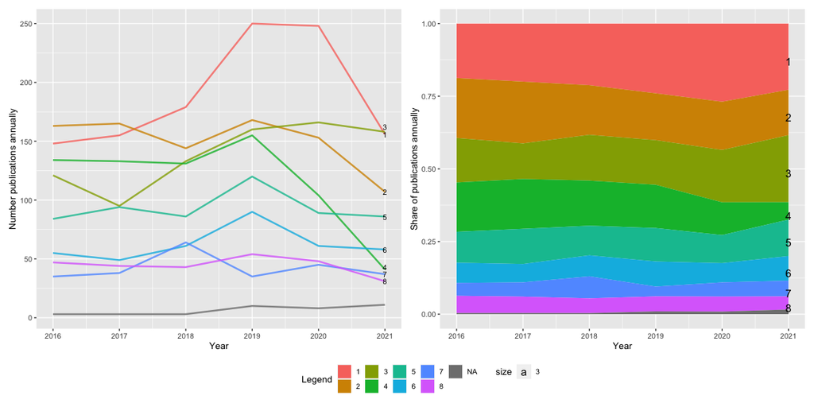

### 5.1.4 Connectivity between the research areas

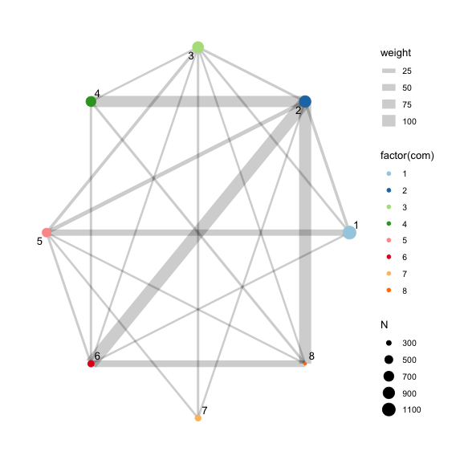

## 5.2 Technical description

In a bibliographic coupling network, the **coupling-strength** between publications is determined by the number of commonly cited references they share, assuming a common pool of references to indicate similarity in context, methods, or theory. Formally, the strength of the relationship between a publication pair $i$ and $j$ ($s_{i,j}^{bib}$) is expressed by the number of commonly cited references.

$$s_{i,j}^{bib} = \sum_m c_{i,m}
c_{j,m}$$

Since our corpus contains publications which differ strongly in terms of the number of cited references, we normalize the coupling strength by the Jaccard similarity coefficient. Here, we weight the intercept of two publications’ bibliography (shared refeences) by their union (number of all references cited by either $i$ or $j$). It is bounded between zero and one, where one indicates the two publications to have an identical bibliography, and zero that they do not share any cited reference. Thereby, we prevent publications from having high coupling strength due to a large bibliography (e.g., literature surveys).

$$S_{i,j}^{jac-bib} =\frac{C(i \cap
j)}{C(i \cup j)} = \frac{s_{i,j}^{bib}}{c_i + c_j -
s_{i,j}^{bib}}$$

More recent articles have a higher pool of possible references to co-cite to, hence they are more likely to be coupled. Consequently, bibliographic coupling represents a forward looking measure, and the method of choice to identify the current knowledge frontier at the point of analysis.

# 6 Additional analysis

## 6.1 Authors, Themes & Journals